# Partisan Media Selectivity and Partisan Identity Threat: The Role of Social and Geographic Context

5/26/2017

## Partisan media

Implicated as potential cause of:

- Ideological polarization (Levendusky, 2013)
- Affective polarization (Garrett et al., 2014)
- Participation (Dilliplane, 2011; Wojcieszak, Bimber, Feldman, & Stroud, 2016)
- Perceptions of media bias (Arceneaux, Johnson, & Murphy, 2012)
- Uncivil political discussion (Gervais, 2014)

## Selective exposure

- Selective approach (I choose my side's programming)
  - Seems more prevalent than active avoidance of the other side (Garrett, 2009)
- But what *causes* it?
  - Partisanship (Iyengar & Hahn, 2009; Johnson, Zhang, & Bichard, 2011; Stroud, 2008; Wicks, Wicks, & Morimoto, 2014)
  - Other leads: Emotional motivations (e.g., Valentino, Banks, Hutchings, & Davis, 2009)
- Let's take a closer look at partisanship

## Partisanship as a social identity

- Party affiliation as a group membership rather than symbolic statement of issue positions or rational choice (Huddy, Mason, & Aarøe, 2015; Iyengar, Sood, & Lelkes, 2012)
- We can apply social identity theory to partisanship (Green, Palmquist, & Shickler, 2004)

## Reinforcing Spirals Model (Slater, 2007; 2014)

- Media are used to maintain social identities
  - Only use as much media as needed for homeostasis
  - Different identities may require different media sources
- Threatened identity = more identity-relevant media use
  - Necessary maintenance
  - Threat removed = less identity-relevant media use

## Reinforcing Spirals Model (Slater, 2007; 2014)

- Media use is a response to the environment rather than perpetually reinforcing
  - Motivation is only for maintenance
  - Competing identities and diverse systems prevent positive feedback loops

## Identity threat

- Numerical distinctiveness
  - Being outnumbered raises identity salience and affiliation (Bettencourt, Miller, & Hume, 1999; McGuire, McGuire, Child, & Fujioka, 1978)
- Threats to value (Branscombe, Ellemers, Spears, & Doosje, 1999)
  - Questioning the merit of the group's practices or morality
- Generally, stronger identification = more entrenchment in the face of threat

## Identity threat in politics

- Red states and blue states
  - Urban-rural divide
  - E.g., are you outnumbered politically in your local area?
- Questioning the beliefs and moral status of opposing parties is normatively acceptable
  - E.g., discussions with those who disagree

## This study

**H1a**: Being a member of the losing party locally will be associated with greater partisan media selectivity.

**H1b**: Discussing politics with members of opposing parties will be associated with greater partisan media selectivity.

**H2a**: The effect of being a member of the losing party locally will be amplified by stronger partisan identity.

**H2b**: The effect of discussing politics with members of opposing parties will be amplified by stronger partisan identity.

## Methods

- N = 1000 sample from YouGov
  - 800 general population sample, 200 black oversample
- Party ID measured on 7-point scale from two questions
- Do you identify as…Republican, Democrat, or Independent
- If Independent, asked if lean toward one or other party
- If one of the parties, asked if "strong" or "not strong"
- Those who provided no party or party lean were excluded

## Measures

- Used program list technique (Dilliplane, Goldman, & Mutz, 2013) to measure media use
  - 67 sources from TV, radio, and websites
  - Yes or no response to watch/listen to/visit source "regularly"
- Sources categorized as left-leaning, right-leaning, or non-partisan
  - 5 political comm. researchers rated each source with option to say "don't know"
  - If majority agreed with identification, then it is used
  - Otherwise, used Lexis-Nexis technique described in Dilliplane (2011)

## Measures

- Respondent ZIP code -> county
  - County-level identity threat = average presidential margin of loss/victory in 2008 and 2012 elections
  - Threat = R margin of victory for Ds, D margin of victory for Rs
- What portion of the people you talk politics with are Republicans, Democrats, members of other parties, and non-party identifiers?
  - Forced sum to 100%
  - Network threat = % out-parties

## Models

Linear regression predicting % of in-party partisan sources out of total number

*Model 1*: **H1a**, **H1b**

*Model 2*: **H2a** (county by identity interaction)

*Model 3*: **H2b** (discussion by identity interaction)

## Models

Focal predictors:

- County-level identity threat (out-party POTUS vote share)
- Network-level identity threat (% out-party discussants)
- Strength of political identity constructed measure
  - 0 = nonpartisan, 1 = lean/not strong partisan, 2 = strong partisan
  - 0 = moderate, 1 = liberal/conservative, 2 = very liberal/conservative
  - Very liberal strong Democrat/very conservative strong Republican = 4
  - Moderate not strong partisan = 1

## Models

Controls:

- Party (1 = Republican)
- Indicator for whether R discusses politics with others
- Number of people with whom R discusses politics with
- Whether any media sources used
- Number of media sources used
- Age, race (black, Hispanic), gender, education, Christian religion

## Results

Model 1

|  | Est. | SE | p |
| --- | --- | --- | --- |
| County-level threat | 4.22 | 2.06 | 0.04 |
| Network-level threat | 1.54 | 2.39 | 0.52 |
| Identity strength | 10.24 | 2.27 | 0.00 |
| Republican | 8.52 | 2.64 | 0.00 |
| # sources | 6.12 | 2.36 | 0.01 |
| # discussants | 4.54 | 2.32 | 0.05 |

## Results

Model 2

|  | Est. | SE | p |
| --- | --- | --- | --- |
| County-level threat | 4.55 | 2.08 | 0.03 |
| Network-level threat | 1.46 | 2.39 | 0.54 |
| Identity strength | 10.11 | 2.25 | 0.00 |
| Republican | 8.42 | 2.63 | 0.00 |
| # sources | 5.81 | 2.35 | 0.01 |
| # discussants | 4.65 | 2.23 | 0.04 |
| County threat x Identity strength | 6.88 | 3.72 | 0.06 |

## Results

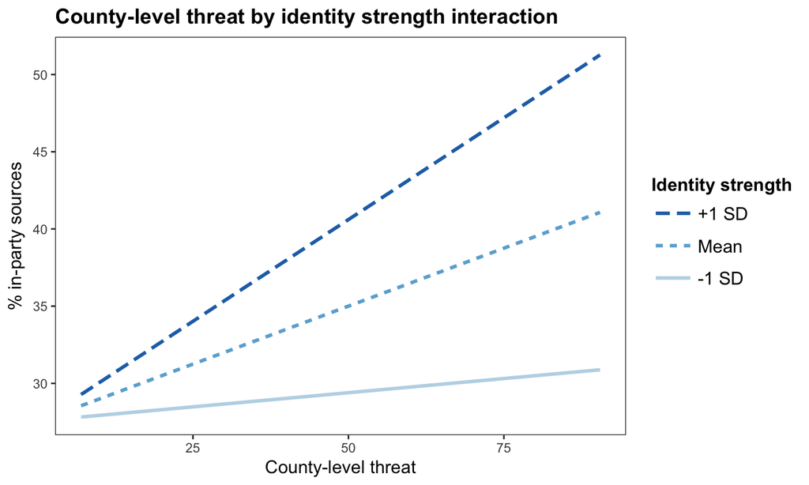

## Results

Model 3

|  | Est. | SE | p |
| --- | --- | --- | --- |
| County-level threat | 4.13 | 2.04 | 0.04 |
| Network-level threat | 1.84 | 2.40 | 0.44 |
| Identity strength | 10.35 | 2.24 | 0.00 |
| Republican | 8.53 | 2.63 | 0.00 |
| # sources | 6.02 | 2.34 | 0.01 |
| # discussants | 4.05 | 2.28 | 0.08 |
| Network threat x Identity strength | 9.13 | 4.19 | 0.03 |

## Results

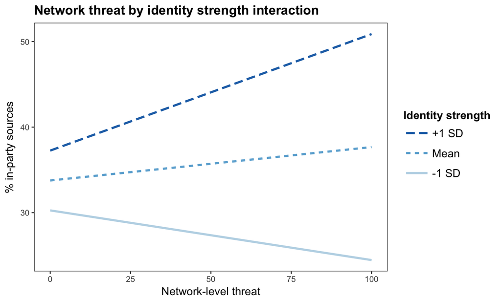

## Recap

**H1a** (county-level threat): Supported

**H1b** (network-level threat): Not supported

**H2b** (network threat by identity strength interaction): Supported

Overall:

- Heterogeneous networks associated with *more* selectivity
  - Especially for stronger partisans
- RSM is a theory invested in over-time effects
  - Those aren't measured here